# National comparisons of early career researchers' scholarly communication attitudes and behaviours - Jamali - 2020 - Learned Publishing - Wiley Online Library

- Skip to Article Content
- Skip to Article Information

**Working off-campus?** Learn about our remote access options

Access byUniversity of Florida Libraries

[Login / Register](https://onlinelibrary.wiley.com/action/showLogin?uri=%2Fdoi%2Ffull%2F10.1002%2Fleap.1313&aria-label=Log+in+or+Register)

[Learned Publishing](https://onlinelibrary.wiley.com/journal/17414857)

[Volume 33, Issue 4](https://onlinelibrary.wiley.com/toc/17414857/2020/33/4) p. 370-384

[figure not shown]

Original Article

Full Access

# National comparisons of early career researchers' scholarly communication attitudes and behaviours

[Hamid R. Jamali](https://onlinelibrary.wiley.com/action/doSearch?ContribAuthorStored=Jamali%2C+Hamid+R)

[David Nicholas](https://onlinelibrary.wiley.com/action/doSearch?ContribAuthorStored=Nicholas%2C+David)

[Eti Herman](https://onlinelibrary.wiley.com/action/doSearch?ContribAuthorStored=Herman%2C+Eti)

[Cherifa Boukacem‐Zeghmouri](https://onlinelibrary.wiley.com/action/doSearch?ContribAuthorStored=Boukacem-Zeghmouri%2C+Cherifa)

[Abdullah Abrizah](https://onlinelibrary.wiley.com/action/doSearch?ContribAuthorStored=Abrizah%2C+Abdullah)

[Blanca Rodríguez‐Bravo](https://onlinelibrary.wiley.com/action/doSearch?ContribAuthorStored=Rodr%C3%ADguez-Bravo%2C+Blanca)

[Jie Xu](https://onlinelibrary.wiley.com/action/doSearch?ContribAuthorStored=Xu%2C+Jie)

[Marzena Świgon’](https://onlinelibrary.wiley.com/action/doSearch?ContribAuthorStored=%C5%9Awigon%27%2C+Marzena)

[Tatiana Polezhaeva](https://onlinelibrary.wiley.com/action/doSearch?ContribAuthorStored=Polezhaeva%2C+Tatiana)

[Anthony Watkinson](https://onlinelibrary.wiley.com/action/doSearch?ContribAuthorStored=Watkinson%2C+Anthony)

First published: 04 June 2020

https://doi.org/10.1002/leap.1313

Citations: 2

## Abstract

The paper compares the scholarly communication attitudes and practices of early career researchers (ECRs) in eight countries concerning discovery, reading, publishing, authorship, open access, and social media. The data are taken from the most recent investigation in the 4‐year‐long Harbingers project. A survey was undertaken to establish whether the scholarly communication behaviours of the new wave of researchers are uniform, progressing, or changing in the same overall direction or whether they are impacted significantly by national and cultural differences. A multilingual questionnaire hosted on SurveyMonkey was distributed in 2019 via social media networks of researchers, academic publishers, and key ECR platforms in the UK, USA, France, China, Spain, Russia, Malaysia, and Poland. Over a thousand responses were obtained, and the main findings are that there is a significant degree of diversity in terms of scholarly communication attitudes and practices of ECRs from the various countries represented in the study, which cannot be solely explained by the different make‐up of the samples. China, Russia, France, and Malaysia were more likely to be different in respect to a scholarly activity, and responses from the UK and USA were relatively similar.

### Key points

- ECRs from China, Russia, France, and Malaysia are more likely to hold different (although moderate) views in respect to a scholarly activity.
- ECRs from the UK and USA are similar in many respects, including being positive towards open science and relying less on external factors (impact factor or number of download) for their decision to read a paper.
- French ECRs appear not to want to do, abide, or follow anything novel or innovative and are very critical of scholarly developments.
- Spanish ECRs are innovative and more positive about publishing open access (OA), while Chinese ECRs are somewhat conservative as they are less likely to publish in OA
- Chinese ECRs are the highest users of social media for testing and conducting research but least likely to use it to share their reputations or build reputations.

## INTRODUCTION

The research published here compares and contrasts the scholarly communication attitudes and practices of early career researchers (ECRs) in eight major countries: China, France, Malaysia, Poland, Russia, Spain, UK, and USA. Arising from the final, quantitative stage of the 4‐year‐long Harbingers research project, which sought to discover whether the new wave of researchers are going to be the harbingers of change (CIBER, 2016‐2020; Nicholas *et al*., 2019), it presents evidence from an international survey that obtained 1,600 responses. Informed and contextualized by its first, qualitative, longitudinal stage, which studied 120 ECRs from seven countries over 3 years (2016–2018), the study explored, *inter alia*, the relevant national characteristics of the participating countries. The findings reported here examine the extent to which ECRs are universal and similar or country‐specific and diverse in their principal scholarly communication views and activities in regard to discovering information, readership, publishing, authorship, open access, and social media.

Thus, the broad aim of this study was establishing whether the scholarly communication attitudes and practices of today's ECRs are universal and uniform, are progressing in the same overall direction, or are impacted significantly by national and cultural aspects.

Its objectives, therefore, were:

- To identify the similarities in the attitudes and practices of ECRs from different countries in the strategic scholarly undertakings.
- To identify the variance in the attitudes and practices of ECRs from different countries in the aforementioned strategic scholarly undertakings.
- To compare and contrast the scholarly communication attitudes and practices of ECRs from different countries and suggest possible country‐specific explanations for the similarities and variance found.

## BACKGROUND AND CONTEXT

As McLuhan (1962) predicted, we do live in a ‘global village’, a term that still captures well the essence of today's borderless information world. The metaphor of the global village, encapsulating the realities fashioned by a vibrant, trans‐national, digital communication that flows worldwide, unimpeded by technical barriers, is nowhere more apt than in the case of the contemporary scholarly enterprise. The scholarly community has historically been international in its scope for the creation of knowledge is based upon the published and informal communications of other scientists, past and present, near and far, and their evaluation of potential new contributions (Price 1963; Schott, 1991). Arguably though, scholarly communication has become ever more borderless, as part and parcel of general globalization trends (Altbach, 2004; Smeby & Trondal, 2005), accelerated by the development of new media (Chen, 2012), as well as policy initiatives on national and supranational levels (Aksnes, Frølich, & Slipersæter, 2008; Smeby & Gornitzka, 2008).

These developments towards globalization are particularly significant for scholars, traditionally living in two worlds – a scientific world with its special norms and rigorous communication structure and a separate ‘outside’ world (Garvey, 1979). Indeed, the scholarly world has a matrix structure: on one axis are the campuses and on the other axis are the research communities (Alpert, 1985). With scholarly interaction and peer recognition of achievements, both on the formal and informal levels, forming such an essential part of their activity, scholarly communities become for the researcher in many ways more visible and real than the physical campuses where they organize their places of work (Agre, 2000). As researchers are first and foremost citizens of the scholarly global village, it may very well be that they adopt similar values and behaviours across nationalities and cultures.

The possibility seems ever more conceivable now as the new wave of researchers – the millennials – join the scholarly workforce. (The term ‘millennials’, also known as “Generation Y", refers to the cohort of people born or experiencing their formative years just before the turn of the millennium. At its broadest sense, millennials are people born between the early 1980s and late 1990s (FEPS – Foundation for European Progressive Studies and ThinkYoung, 2018). As Burstein (2013) argues, while every generation is influenced by and, in some sense, is a product of its times, it must be all the more so where millennials are concerned. Living in today's connectivity‐governed global village, they experience worldwide events in a way that no other generations have: for them, both international crises/wars and cross‐national trends in cultural norms are more present than to generations before. As a result, they are the first truly global generational cohort who, indeed, see themselves and greatly value being part of a global community, part of the global village (Burstein, 2013; Schewe *et al*., 2013; Wireless World Research Forum, 2017). The findings of the Global Shapers Annual Survey (World Economic Forum, 2017) bear testimony to this state of affairs: ‘for a large majority of young people, identity is not about region, geography, religion or ethnicity; they simply see themselves as ‘human’ (40.8%)…. Young people feel they are united simply because they exist in the same world together. Both as individuals and as a collective, they share similar concerns and desires’ (p.29).

The similarity in attitudes and practices of millennials is borne out by empirical evidence, although given the effects of demographic factors, care must be taken not to paint the entire generation with the same brush. Nevertheless, it is telling that, while technology use varies widely by country, younger people, whether in advanced or emerging economies, are more likely to be digitally connected: to have smartphones, access the internet, and use social media (Pew Research Center, 2019). The specific example of a comparative study of the online shopping behaviours of Australian and American millennials provides further proof of the basic similarity characterizing them as a generation: the unique features attributable to them have been found to influence their shopping practices in a similar way, with only small differences (Dharmesti, Dharmesti, Kuhne, & Thaichon, 2019). Indeed, in a study that sought to establish expressly whether millennials are the same the world over via a comparison of this generational cohort in the USA, Sweden, and New Zealand, they were found to be alike in many ways, most notably for our purposes here on the value dimensions of openness, collaboration/teamwork, and security, although, importantly, they manifested some differences, too, stemming from their cultural upbringing in each country (Schewe *et al*., 2013). The study, of course, only focused on a few wealthy countries from the Global North and not the world. It is hardly surprising to find then that, according to a Wireless World Research Forum White Paper (2017), millennials can be characterized in similar words, even though in different locations, there are differences in how important some of the features attributed to them are considered to be.

There can be little doubt then that life in the scholarly global village can be conducive to greater uniformity in attitudes and practices, and particularly so where millennials are concerned. However, there is also an extensive body of literature that testifies to the diversifying impacts of national cultures and local circumstances on the values and activities of populations, although very little of it pertains directly to scholars. Ranging from theoretical explorations of the roots of cultural diversity among nations and their effects on interpersonal communications (Chhokar, Brodbeck, & House, 2007; Hall, 1976; Hofstede, 2001; Komlodi, 2005; Schwartz, 1999; Triandis, 1995) to studies building on these theories to demonstrate and explain what actually happens on the ground (Khosrowjerdi, Sundqvist, & Byström, 2019; Lebedko, 2014; Makri, Papadas, & Schlegelmilch, 2019; Selim, 2017; Vitkauskaite, 2016), there is a wealth of research on culture‐rooted, and at times policy‐driven, developments in a cross‐national context.

The existence of national culture‐driven attitudes, social perceptions, preferences, and behavioural responses is best exemplified by the take‐up of social networking sites (SNS), such as Facebook. The adoption and usage patterns of SNS, arguably among the most strategic players in the globalization processes of the past decade or so – available and much used as they are worldwide, and of a particular appeal to millennials, too – have nevertheless repeatedly been found to be in many ways country‐specific (Jackson & Wang, 2013; Kalia, Ben Dahmane Mouelhi, Tebessi Hachana, Malek, & Dahmen, 2019; Kim, Sohn, & Choi, 2011; Makri & Schlegelmilch, 2017; Ozer, Karpinski, & Kirschner, 2014; Sheldon, Rauschnabel, Antony, & Car, 2017).

Interestingly, however, where scholarly populations are concerned, while there is an abundance of studies that cover traits of their communicational attitudes and activities in general or on the individual country level, attempts at comparative, cross‐national approaches to the topic have been few and far between. Jamali *et al*. (2014), for one, did explore the possibility of geographical similarities and differences in academic researchers' reading, citing, publishing, and trust assigning practices, finding indications of both. Taking a similar approach to an international comparison of journal publishing and citing behaviours, using a different methodology, Didegah, Thelwall, and Gazni (2012) traced most publications in, and citations to, all journals they examined to scientifically and economically developed countries. However, both these studies made comparisons of scholarly behaviour through the prism of the relevant countries' level of economic development, rather than that of nation‐specific cultural settings and/or local, policy‐driven circumstances.

Additional studies that also targeted specifically the scholarly population focused each on a particular segment and specific aspect of their professional communication behaviour, inevitably rendering our appreciation of the developments in this area patchy. Thus, for example, Xu, Yang, Cong, and Zeng's (2015) study compared Chinese and American researchers' attitude to and usage of social media to find that cultural orientations leave their mark on scholarly views and behaviours. Still, as the study focused on general SNS, such as Facebook and Twitter, rather than specifically scholarly‐oriented ones, such as ResearchGate or Academia.edu, its results cannot fully represent the range of scholarly communication that takes place on the social web. More recently, Haddow and Hammarfelt (2019) looked at metrics use among social sciences scholars in Australia and Sweden. According to their findings, overall use was rather low, although the Australians did report use twice as much as their Swedish peers. Shehata (2019), too, investigated scholarly communication behaviour among social sciences scholars but also among humanities scholars, comparing for the purpose Egyptian and Saudi Arabian researchers' practices. Merga and Mason (2020) looked at sharing research practices among Australian and Japanese ECRs and found that, while ECRs may use a range of media to communicate outside of academia, they need more support and training. These studies, obviously limited in their generalizability to the entire scholarly community, as their respective participants do not represent many countries or even all major disciplinary areas, nevertheless indicate that scholarly communication practices vary by country, with institutional policies and processes frequently associated with the choices made.

Given this dearth of literature on the topic, setting out to establish, as this study endeavours to do, whether the scholarly communication attitudes and practices of the new wave of researchers are universal and uniform or, perhaps, country‐specific thus will fill a gap in our understanding of the workings of the scholarly enterprise. After all, ECRs are, in quite a few respects, the harbingers of change in the scholarly community (Nicholas *et al*., 2019, 2020), which renders their views and attitudes particularly important.

## METHODS

After a 3‐year longitudinal interview study involving around 120 ECRs (for more information, see Nicholas *et al*., 2019; CIBER, 2016‐2020) from China, France, Malaysia, Poland, Spain, the UK and USA, the project was extended by a quantitative phase. The chosen countries – China, France, Malaysia, Poland, Russia, Spain, the UK and USA – were selected because, with the exception of Russia, they were featured in the preliminary qualitative study, which prepared the ground for the study reported here. It also meant we had a good understanding of the workings of the scholarly communication systems in these countries and were in a good position to explain the data and determine its significance. Russia was recruited because it was felt we knew very little about the scholarly communications of a major scientific force, and it was necessary to fill that vacuum, and as with all the other case study countries, there were researchers on the ground who could assist in the distribution of questionnaires and who would translate them where necessary and furnish the important context.

A questionnaire survey was designed and pilot tested and distributed online via SurveyMonkey. It was made available in June 2019 in English, Chinese, French, Polish, Russian, and Spanish. The questionnaire featured a comprehensive range of questions, including metrics, ethics, peer review, discovery, reading, publishing, authorship, open access, and social media, although only the last six are covered in this paper because of space restraints. The survey was distributed internationally, but this paper focuses on just the eight countries previously mentioned for the reasons already given. Some of the other results of the survey have already been published (Jamali *et al*., 2019; Nicholas *et al*., 2020).

Because there was no single sampling frame for ECRs or even a universal definition (the two are related), a broad‐brush approach to dissemination was adopted, with the questionnaire distributed via social media networks of researchers, academic publishers (Wiley, Emerald, Cambridge University Press, Public Library of Science), and key ECR platforms (Eurodoc, Voice of Young Science). Because of the approach, the questionnaire began with a screening question to filter out those respondents who did not broadly meet the ECR definition we adopted at the beginning of the Harbingers study:

*‘*We are most interested in hearing from researchers who are generally not older than 35, who either have received their doctorate and are currently in a research position or have been in research positions but are currently doing a doctorate. In neither case should researchers be in an established or tenured position. But if all of that is just too complex if you believe you are an early career researcher that is all that counts!’

A total of 1,600 valid responses were received, making it one of the biggest studies of its kind. Of these, 1,051 responses belonged to the eight countries that are compared in this paper.

For ethical reasons, respondents were allowed to skip any question and leave the questionnaire at any point if they wished to. Therefore, about 10% of respondents skipped some of the demographic questions. Another limitation was that, due to various means of distribution, it is not possible to calculate a response rate. The analysis that follows includes cross‐tabulation with frequency and percentage, chi‐square, and Cramer's *V* values for categorical data and mean values and ANOVA test for Likert questions. Cramer's *V* shows the strength of association, and it is considered weak if >0.05, moderate if >0.10, strong if >0.15, and very strong if >0.25. The options in Likert questions were “Not at all/Very little/A little/Somewhat/To a great extent”, for which mean values were calculated based on their numerical values (from 1 to 5). We ran both parametric and non‐parametric tests, and the results were similar, and therefore, we have used parametric statistics in this paper where possible (Norman, 2010), which includes ANOVA and Tukey post‐hoc test. ANOVA tables include mean and standard deviation for each country that is separated with a comma (*M*, *SD*). The last two columns include *F* values and Eta‐squared (*η*<sup>2</sup>). Eta‐squared values have been included as effect size values that show the strength of the effect. A value of 0.15 means that 15% of all variance of the given item (e.g. reading full text on smartphone) is attributed to nationality. An Eta‐squared value of 0.01 is considered a small effect, 0.06 is considered medium effect, and 0.14 is considered a large effect. There are eight countries, and each country is compared pairwise with the other seven using post‐hoc test. To avoid lengthy tables, a few formatting features, as given below, were used to mark the pairwise differences in ANOVA tables.

- All countries in light grey cells have pairwise difference with the country with a dark grey cell.
- All countries with italic values have pairwise difference with the country in bold and italic.
- All countries with underline values have pairwise difference with the country in bold and underline.
- All countries with two asterisks (**) have pairwise difference with the country with one asterisk.

All of the data (figures and tables) presented in this article are the results of the questionnaire survey. The interview data from the first stage of the study have been only used to place the survey data in context and explain it, and they are taken from reports previously published (see Nicholas *et al*., 2019 for a summary). Because the interview data were taken from a small population that is different in a number of demographic characteristics (most notably, the interview study did not include arts and humanities ECRs), it is neither possible to make comparisons between the two datasets nor can we be 100% accurate in our use of these data.

## FINDINGS

### Demographics

Overall, 1,051 ECRs from the eight countries completed the questionnaire successfully, of which the largest percentage (24%) was from China and the smallest was from Spain (8%) (Fig. 1).

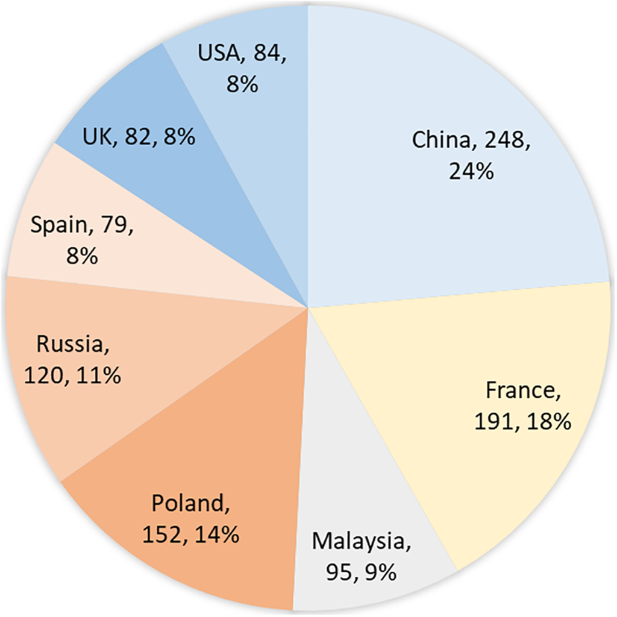

**Figure 1**

Open in figure viewer[PowerPoint](https://onlinelibrary.wiley.com/action/downloadFigures?id=leap1313-fig-0001&doi=10.1002%2Fleap.1313)

Distribution of respondents by country (*N* = 1,051).

Table 1. Demographics of respondents by country

| All item | All (*N*) | All (%) | China (%) | France (%) | Malaysia (%) | Poland (%) | Russia (%) | Spain (%) | UK (%) | USA (%) |
| --- | --- | --- | --- | --- | --- | --- | --- | --- | --- | --- |
| Gender |  |  |  |  |  |  |  |  |  |  |
| Female | 570 | 54.2 | 44.8 | 53.9 | 56.8 | 60.5 | 60.8 | 54.4 | 61 | 52.4 |
| Male | 454 | 43.2 | 48.8 | 45.5 | 43.2 | 38.8 | 38.3 | 44.3 | 35.4 | 42.9 |
| Prefer not to say | 25 | 2.4 | 6.0 | 0.5 | 0 | 0.7 | 0 | 1.3 | 3.6 | 4.8 |
| No answer | 2 | 0.2 | 0.4 | 0 | 0 | 0 | 0.8 | 0 | 0 | 0 |
| Age |  |  |  |  |  |  |  |  |  |  |
| 21–25 | 120 | 11.4 | 1.6 | 15.7 | 4.2 | 14.5 | *37.5* | 10.1 | 6.1 | 2.4 |
| 26–30 | 401 | 38.2 | 32.7 | 51.3 | 12.6 | 52.6 | 37.5 | 31.6 | 41.5 | 31 |
| 31–35 | 355 | 33.8 | 44.8 | 28.8 | *49.5* | 22.4 | 24.2 | 30.4 | 32.9 | 33.3 |
| 36–40 | 123 | 11.7 | 19.0 | 2.6 | 21.1 | 7.2 | 0.8 | 15.2 | 11 | 21.4 |
| 40+ | 49 | 4.7 | 1.6 | 1.6 | 12.6 | 3.3 | 0 | 10.1 | 8.5 | 11.9 |
| No answer | 3 | 0.3 | 0.4 | 0 | 0 | 0 | 0 | 2.5 | 0 | 0 |
| Subject |  |  |  |  |  |  |  |  |  |  |
| Health sciences | 84 | 8 | 3.6 | 7.3 | 8.4 | 7.2 | 1.7 | 8.9 | *17.1* | *22.6* |
| Life sciences | 193 | 18.4 | 6.0 | 22.0 | 18.9 | 26.3 | 12.5 | 24.1 | 23.2 | 29.8 |
| Physical sciences and engineering | 272 | 25.9 | 31.5 | 27.7 | 27.4 | 26.3 | 33.3 | 8.9 | 24.4 | *9.5* |
| Social sciences | 370 | 35.2 | 45.2 | 32.5 | 40 | 25.7 | 30 | 40.5 | 25.6 | 35.7 |
| Arts and humanities | 119 | 11.3 | 9.3 | 9.4 | 5.3 | 14.5 | *22.5* | 17.7 | 9.8 | 2.4 |
| No answer | 13 | 1.3 | 4.4 | 1 | 0 | 0 | 0 | 0 | 0 | 0 |
| Highest degree completed |  |  |  |  |  |  |  |  |  |  |
| Bachelor's degree | 39 | 3.7 | 0.8 | *0* | 4.2 | *0* | *17.5* | 3.8 | 3.7 | 7.1 |
| Master's degree | 372 | 35.4 | *7.7* | 45.5 | 27.4 | *67.8* | *42.5* | 59.5 | 24.4 | 22.6 |
| Doctorate degree (PhD) | 579 | 55.1 | 85.9 | 50.8 | 66.3 | 21.1 | *27.5* | 34.2 | 72 | 65.5 |
| Professional degree (MD, JD, *etc*.) | 35 | 3.3 | 2.0 | 2.1 | 2.1 | 11.2 | 0.8 | 2.5 | 0 | 4.8 |
| Other/prefer not to say | 23 | 2.2 | 2.8 | 1.0 | 0 | 0 | 11.7 | 0 | 0 | 0 |
| No answer | 3 | 0.3 | 0.8 | 0.5 | 0 | 0 | 0 | 0 | 0 | 0 |
| Job position |  |  |  |  |  |  |  |  |  |  |
| Doctoral student | 356 | 33.9 | *8.1* | 49.2 | 16.8 | *69.7* | 30 | 54.4 | 23.2 | 26.2 |
| Post‐doctoral student/researcher | 176 | 16.7 | 14.5 | 31.4 | 8.4 | 9.2 | 0 | 7.6 | 42.7 | 20.2 |
| Academic researcher | 154 | 14.7 | 32.7 | 2.6 | 28.4 | 10.5 | 4.2 | 5.1 | 8.5 | 10.7 |
| Non‐academic researcher | 52 | 4.9 | 4.8 | 2.6 | 5.3 | 0 | 19.2 | 2.5 | 1.2 | 4.8 |
| Non‐tenure track faculty | 50 | 4.8 | 5.2 | 4.7 | 0 | 3.3 | 8.3 | 11.4 | 1.2 | 3.6 |
| Assistant professor/lecturer | 171 | 16.3 | 33.1 | *2.1* | 35.8 | *2.6* | *6.7* | 2.5 | 17.1 | 27.4 |
| Other | 86 | 8.2 | 0.8 | 6.8 | 5.3 | 3.9 | *30* | 16.5 | 6.1 | 7.1 |
| No answer | 6 | 0.6 | 0.8 | 0.5 | 0 | 0.7 | 1.7 | 0 | 0 | 0 |

### Looking for information

In general, the most common way of looking for and finding scholarly material is to use Google Scholar (GS) (Table 2). There are big differences between the case study countries, with GS least used by the Chinese ECRs (*M* = 3.4), where it is banned (but accessed via virtual private networks), and Russian ECRs (*M* = 3.4) who tend to use Google instead because it is faster and simpler to search given their lack of proficiency in English. In addition, because of the poor coverage of Russian journals by GS, ECRs prefer to search national aggregators, such as the Russian Science Citation Index and CyberLeninka or Yandex, the Russian search engine. GS is most used by Malaysians (*M* = 4.3) and Americans (*M* = 4.2). GS is attractive to Malaysian researchers because they typically publish and search in the English language (English is the medium of instruction in universities), and they use it when they are just at the beginning of their searches. Free access to the many full‐text articles furnished by a GS search is another advantage, especially as Web of Science (WoS) is expensive to use. There are statistically significant pairwise differences between China and France, China and Malaysia, and China and the USA (coloured cells). There are also significant differences between Russia and Poland, Russia and Malaysia, and Russia and USA (cells with italic values) and, finally, between Poland and Malaysia (cells with underlined values).

Table 2. To what extent are the following statements true about how you look for and find scholarly material? (*M*, *SD*) *(N* ≈ 1,015, *df* = 7, *p* < 0.05)

|  | China | France | Malaysia | Poland | Russia | Spain | UK | USA | Total | *F* | *η*<sup>2</sup> |
| --- | --- | --- | --- | --- | --- | --- | --- | --- | --- | --- | --- |
| I rely on Google Scholar to search for and find scholarly publications | 3.4, 1.4 | 3.8, 1.4 | *4.3*, *0.9* | *3.8*, *1.3* | *3.4*, *1.3* | 3.7, 1 | 3.8, 1.3 | *4.2*, *1* | 3.7, 1.3 | 8.6 | .06 |
| I rely on Google to search and find scholarly publications | *3*, *1.4* | *3.7*, *1.3* | *4.4*, *0.9* | *3.8*, *1.2* | *3.7*, *1* | **2.9, 1.1** | 3.3, 1.4 | *3.7*, *1.2* | 3.5, 1.3 | 17.4 | .11 |
| I rely on PubMed to search and find scholarly publications | *2.1*, *1.3* | *2.2*, *1.6* | *2.6*, *1.3* | *2.5*, *1.7* | *2.2*, *1.3* | *3.8*, *1.2* | *2.6*, *1.5* | *3.4*, *1.5* | 2.5, 1.5 | 15 | .10 |
| I search for scholarly publications on a smartphone | *2.3*, *1.2* | *1.8*, *1* | *3.3*, *1.3* | *2.6*, *1.4* | **2.8, 1.2** | *2.6*, *1.3* | *2.3*, *1.3* | *2.5*, *1.3* | 2.5, 1.3 | 16.6 | .10 |
| I search for non‐peer reviewed content, too, for my research (for example, blogs or presentations) | 2.9, 1.3 | 2.8, 1.2 | *3*, *1.3* | *2.5*, *1.3* | *3.1*, *1.1* | 2.4, 1.2 | 2.9, 1.1 | 2.7, 1.1 | 2.8, 1.2 | 3.8 | .03 |

Malaysian ECRs also used Google more than ECRs in other countries, where it was marginally more popular than GS, and the difference between Malaysia and all other countries is significant. In fact, Google is the first ranked website used in Malaysia with monthly traffic of 468,960,000 in 2019 (Digital 2019 Malaysia, 2019). Google was least used in Spain for finding scholarly material, and the difference between Spain and most countries (except the UK and China) is statistically significant. From the previous interviews, we learned that the reason for this is that Spanish ECRs largely trust WoS because, when it comes to information retrieval, they value relevance and precision above all else, and they are looking primarily for impact factor (MF) papers to read and cite, and they do not have time for filtering the results obtained from a Google search. PubMed was used in Spain more than in other countries (largely for the reasons given above), and it was the least used in China. PubMed covers health sciences and biomedical research, and the Spanish result is explained by the fact that, although only 8.9% of ECRs were health scientists, there was also a medical oriented life science group (24.1%) (see Table 1). In the case of China, only 3.6% of Chinese ECRs were health scientists.

Searching for scholarly material on a smartphone was most common among Malaysians (*M* = 3.3), and this is partly explained by the fact Malaysia is a very mobile friendly country, with 89.4% of the population – and virtually the whole of the 20–35 years age group – accessing the web via a smartphone. Smartphone use is least common among French ECRs (*M* = 1.8) who had significant differences with all other countries except the UK. Russian (*M* = 3.1) and Malaysian (*M* = 3.0) ECRs were more likely to search for non‐peer reviewed content for their research and Spanish ECRs the least likely to (*M* = 2.4), which might be because of their competitive academic environment and the pressure to publish in journals with an impact factor. The Malaysian result is connected to the widespread use of Google because it does not filter searches by peer reviewed materials, and this holds true for the Russians as well (plus they use Yandex, which does not filter either).

### Reading practices

When it comes to reading practices, there are real differences between countries (Table 3). Take, for instance, the use of smartphones, with Malaysian ECRs the most likely to use them for reading purposes (*M* = 3.2), and the difference between Malaysia and all other countries except Russia is statistically significant. The Malaysian result is connected to the high use of Google and the ownership of smartphones. In contrast, French ECRs (*M* = 1.6) barely use smartphones in this context, and the difference with China, Poland, and Spain is statistically significant. The low use of smartphones by French ECRs is easily explained. The previous interviews told us that they are very careful about separating personal and professional life, and the smartphone they use will be a personal, rather than a corporate, one, and they, therefore, will not use it for professional purposes (this was also true to a certain extent in the case of UK and USA ECRs). There are also statistically significant differences between UK and Poland and UK and China that are marked using asterisks in the tables.

Table 3. To what extent are the following statements true about your current practices concerning reading? (*M*, *SD*) *(N* ≈ 1,040, *df* = 7, *p* < 0.05)

|  | China | France | Malaysia | Poland | Russia | Spain | UK | USA | Total | *F* | *η*<sup>2</sup> |
| --- | --- | --- | --- | --- | --- | --- | --- | --- | --- | --- | --- |
| I read the full text of scholarly publications on a smartphone | **2.4, *1.1* | *1.6*, *1* | 3.2, 1.3 | **2.5, 1.3 | *2.8*, *1.2* | *2.2*, *1.1* | *1.9, *1.1* | *2*, *1* | 2.3, 1.2 | 26.3 | .15 |
| The number of downloads a publication obtains influences my decision to read it | 3.1, 1.1 | *2*, *1.2* | *3*, *1.3* | *2.4*, *1.2* | **2.6, 1.1 | *2.3*, *1* | *1.9, *1.1* | *2*, *1.1* | 2.5, 1.2 | 24.8 | .15 |
| The author's country of affiliation influences my decision to read a publication | 2.8, 1.1 | 2.3, 1.2 | *2.6*, *1.2* | 2.5, 1.3 | 2.4, 0.9 | 2.3, 1.1 | *2*, *1.1* | 2.1, 1.1 | 2.4, 1.2 | 5.9 | .04 |
| Suggestions/recommendations from social media influence my decision to read a publication | *3.2*, *1* | 1.9, 1.1 | 2.9, 1.2 | *2.7*, *1.4* | *2.6*, *1.1* | 2.8, 1.2 | *2.7*, *1.2* | 2.8, 1.2 | 2.7, 1.3 | 19.5 | .12 |
| The ease of access to a publication influences my decision to read | 3.4, 1.1 | *4*, *1.2* | *4.5*, *0.9* | **4.2, 1** | *3.6*, *1.2* | *3.9*, *1.2* | *4*, *1.1* | 4, 1.2 | 3.9, 1.1 | 12.8 | .08 |
| Rank and impact factor of an article's journal influences my decision to read it | *4.1*, *1* | 2.6, 1.3 | 3.8, 1.1 | 3.9, 1.3 | *3.5*, *1* | 3.7, 1.2 | *3*, *1.2* | *3.4*, *1.2* | 3.5, 1.3 | 29 | .17 |
| The journal's prestige (standing in the community) influences my decision to read it | 4.3, 0.8 | *3.4*, *1.2* | *3.9*, *1* | *4*, *1.2* | 3.7, 1 | 3.8, 1 | **3.5, 1.1** | 3.8, 1 | 3.8, 1.1 | 12.3 | .08 |

With regard to the rest of the reading practices, it is clear that external factors, such as the number of downloads, author's affiliation, journal's prestige and impact factor, and social media recommendations, determine what articles Chinese ECRs read more so than in other countries. The influence of these external factors seems to be lower in the case of ECRs in the more developed countries (i.e. UK, USA, and France). French ECRs were least likely to be influenced by social media suggestions for their reading (*M* = 1.9), and the difference between France and all other countries is significant. French ECRS explained in the interviews that they see social media as ‘toys’. Other interesting findings are as follows:

- How ease of access generally has a big influence on ECR's reading in all countries, and especially so in Malaysia (*M* = 4.5), where the popularity of Google and smartphones explains this. The benefits of using Google and a smartphone for them are ease of access and ease of use. We have found elsewhere that, when Malaysian ECRs are pressed for time, the ease of availability of a source overtakes considerations about its quality (Abrizah, Xu, & Nicholas, 2017).
- In China, material coming out of more developed countries is prized a little more highly (*M* = 2.8).
- Downloads are not regarded at all in the UK, where only citation metrics prevail.
- Finally, a stand‐out readership result is that China ECRs are markedly influenced in what they read by metrics and ranking. We know from the interview data that this is because of how highly and widely these factors are prized throughout the scholarly and reputational system.

### Publishing practices

Clearly, the most common global practice among ECRs in all countries is to publish in journals perceived to be highly ranked (*M* = 4.2), and this is especially so in the case of China and Poland (both *M* = 4.5) (see Table 4). This was followed by being guided to where to publish by quantifiable metrics (*M* = 3.8), with a markedly higher score registered by Polish ECRs (*M* = 4.4). The two Polish scores are a direct consequence of government‐led initiatives to overhaul the existing scholarly communication system in order to better compete on the international stage, and this has led to the introduction of a new list of accredited journals, which favours international journals with good IF ratings over local journals – 100 reputational points compared to 20 points (Ministry of Science and Higher Education in Poland, 2018, 2019). Spanish ECRs showed a similar preference, and this is thought to be because of the highly competitive environment in which they face a difficult path to obtaining tenure, resulting in highly valuing publication in high impact journals. French and Russians rated these two practices lower than the other countries. In the case of the latter, this is being addressed by a number of initiatives that seek to raise the ranking profiles of Russian scientists and universities, so this might change in the next few years. In the case of France, it really is very much because of the widespread dislike of metrics in any guise, which the data in Table 4 show.

Table 4. To what extent are the following statements true about your current practices concerning publishing? (*M*, *SD*) *(N* ≈ 1,005, *df* = 7, *p* < 0.05)

|  | China | France | Malaysia | Poland | Russia | Spain | UK | USA | Total | F | η<sup>2</sup> |
| --- | --- | --- | --- | --- | --- | --- | --- | --- | --- | --- | --- |
| I share my work in subject or institutional repositories before publication in a journal | 2.3, 1.3 | *2*, *1.5* | *2.8*, *1.3* | *2.1*, *1.4* | 2.5, 1.1 | 2.3, 1.4 | 3.1, 1.7 | 2.4, 1.3 | 2.4, 1.4 | 6.2 | .04 |
| I look to publish in journals perceived to be highly ranked for career‐advancing reasons | *4.5*, *0.7* | *4.1*, *1.1* | *4*, *0.9* | **4.5, 0.8** | 3.7, 0.9 | 4.4, 0.8 | 4.3, 0.9 | *4.1*, *1.1* | 4.2, 0.9 | 13.4 | .09 |
| I rely on quantifiable metrics (such as the impact factor) when deciding which journal to publish in | *3.8*, *1* | *3.4*, *1.4* | *3.9*, *0.9* | 4.4, 1 | **3.5, 1** | *4.1*, *1* | 3.7, 1.1 | 3.7, 1.1 | 3.8, 1.1 | 12.4 | .08 |
| I use social media (Twitter, Facebook, blogs *etc*.) to promote my research | 2.1, 1.1 | *2.4*, *1.5* | 2.7, 1.3 | **2.5, 1.5** | 2.5, 1.1 | *3.1*, *1.5* | *3*, *1.5* | 2.9, 1.4 | 2.5, 1.4 | 8.2 | .05 |
| I share links to and news about my publications on social media | 2.3, 1.1 | *2.3*, *1.5* | 2.7, 1.3 | 2.6, 1.6 | 2.6, 1.1 | *3*, *1.4* | *3*, *1.5* | *3.1*, *1.4* | 2.6, 1.4 | 6.4 | .04 |
| I post the peer‐reviewed version of my publications on social media based scholarly platforms (e.g. ResearchGate) | 2.4, 1.3 | *3.1*, *1.6* | 3, 1.5 | *3.2*, *1.7* | *2.4*, *1* | *3.4*, *1.5* | 3, 1.5 | *3.2*, *1.6* | 2.9, 1.5 | 8.7 |  |
| I don't share research data/results before their publication for fear of losing my competitive edge. | 3.6, 1 | *2.8*, *1.5* | **3.4, 1.4** | *3.7*, *1.5* | *2.9*, *1.1* | 3.2, 1.4 | *2.9*, *1.4* | 3.3, 1.4 | 3.3, 1.4 | 9.4 | .06 |
| I utilize social media to disseminate less formal/interim outputs (e.g. presentations, working papers). | 2.3, 1.1 | 1.6, 1.1 | *2.5*, *1.2* | *2*, *1.3* | *2.7*, *1.1* | **2.1, 1.3** | 2.4, 1.4 | 2.2, 1.2 | 2.2, 1.2 | 12.1 | .07 |
| I make an effort to embrace open science principles (i.e. greater transparency, more sharing) in my research work | 3.6, 0.9 | 3.8, 1.2 | 3.5, 1.1 | 3.6, 1.1 | *3.4*, *0.9* | 3.9, 1 | 4, 1.1 | *3.9*, *1* | 3.7, 1.1 | 4.4 | .03 |

Sharing works in repositories – not generally a very common or prized activity – was most common among ECRs in UK (*M* = 3.1), and this is probably because of the dictates of the Research Evaluation Framework (REF), which mandates this practice. With respect to the three statements about the use of social media in dissemination, Spanish ECRs were the most proactive. Spanish ECRs look to obtain visibility through the number of readings their work attracts as a first step to obtaining their reputation through citations. Chinese ECRs, on the other hand, were distinctly lukewarm towards social media and did not use it to promote or disseminate research, which is interesting because they are prolific social media users in the wider context. French ECRs were the least likely to utilize social media to disseminate their less formal/interim outputs.

Generally, the US and UK ECRs were more positive about sharing than the other countries, and this could be because they are relatively experienced and are, therefore, more confident about sharing after publication, and they believe they have something to say. Having said that, it is Spanish ECRs who use ResearchGate the most for doing this.

### Authorship

ECRs were asked whether they had published a co‐authored paper, and 82.3% (865 of 1,051) had done so (Table 5). We asked the question because co‐authorship introduces complexities for ECRs in terms of their roles, responsibilities, and influences. Those who said they had were asked whether they had any influence on authorship decisions. Russians had the highest influence, with only 4.4% saying No and 55.6% saying they had a big influence, while the Chinese had the lowest influence, with 19.4% saying No and only 33.2 saying they had a big influence. ECRs were then asked about four common types of authorship policies, which arose from the interview stage of the study. Figure 2 provides a visual demonstration of which of these policies are most common in the individual case study countries, and it can be seen that there are big differences. Thus, in China, policies related to the first author figure the highest and by a considerable margin. In Poland, Malaysia, and Spain, it was a similar story, although the policy was not as dominant. In France and Russia, the prime interest is the order in which authors are named, whereas in the USA, the concern is mainly who should be named as author. The UK is unusual in that it does not really exhibit one major concern, with policies about the order of naming and who should be named being of equal but not dominant. Malaysia is at the other end of the scale to the UK, with all four policies obtaining a reasonably high level of concern. The low mention of corresponding author policies in Spain is because the first author is typically also the corresponding author.

Table 5. Do you feel you have an influence on authorship decisions when you co‐author? *(X*<sup>*2*</sup> = 55.9, *df* = 14, *p* < 0.005, *V* = 0.18)

|  |  | China | France | Malaysia | Poland | Russia | Spain | UK | USA | Total |
| --- | --- | --- | --- | --- | --- | --- | --- | --- | --- | --- |
| Yes, a big influence | N | 72 | 44 | 16 | 59 | 50 | 31 | 31 | 29 | 332 |
|  | % | 33.2 | 30.3 | 18.6 | 50 | 55.6 | 49.2 | 42.5 | 39.7 | 38.4 |
| Yes, some influence | N | 103 | 83 | 57 | 49 | 36 | 28 | 37 | 33 | 426 |
|  | % | 47.5 | 57.2 | 66.3 | 41.5 | 40 | 44.4 | 50.7 | 45.2 | 49.2 |
| No | N | 42 | 18 | 13 | 10 | 4 | 4 | 5 | 11 | 107 |
|  | % | 19.4 | 12.4 | 15.1 | 8.5 | 4.4 | 6.3 | 6.8 | 15.1 | 12.4 |
| Total | N | 217 | 145 | 86 | 118 | 90 | 63 | 73 | 73 | 865 |

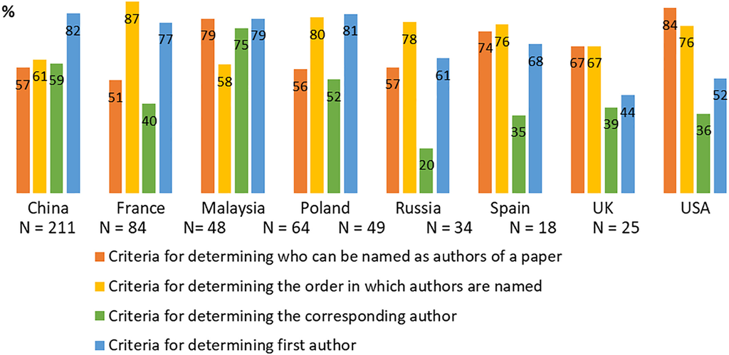

**Figure 2**

Open in figure viewer[PowerPoint](https://onlinelibrary.wiley.com/action/downloadFigures?id=leap1313-fig-0002&doi=10.1002%2Fleap.1313)

Characteristics of authorship policies among survey participants (*N* = 533).

### Open access

When asked if they publish papers open access (OA), Chinese ECRs were mostly likely to say they did not publish open access (49.2%) (Fig. 3). This is an interesting finding as the Chinese produce the largest number of scholarly papers in the world (Tollefson, 2018). There is a considerable difference between the Chinese and all the other countries despite alleged support from government for open access and the European proposal for OA, Plan S (https://www.coalition-s.org/; Schiermeier, 2018). The British say they publish in OA sources most frequently, which is perhaps surprising given that the earlier interview data showed a positive attitude towards OA but a constrained practice due to reputational concerns. The Russians are the most likely to publish OA, although Plan S is not actually supported by the Russian Academy of Sciences, so we need to look elsewhere for an explanation. The reason may be due to a misunderstanding. Historically, it has been free to publish in scholarly journal for ‘aspirants’ (postgraduate students who are preparing for their dissertations). Nowadays, however, many journals indexed by Scopus/WoS charge Author Processing Charges (APC) so it might be the case that ECRs might have mixed the terms OA and free, meaning that they publish a lot in free journals.

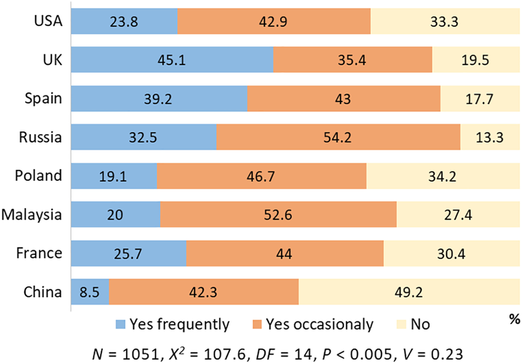

**Figure 3**

Open in figure viewer[PowerPoint](https://onlinelibrary.wiley.com/action/downloadFigures?id=leap1313-fig-0003&doi=10.1002%2Fleap.1313)

Do you publish papers open access by country (percentages)?.

OA publishing is thought to have many advantages by ECRs, but two stand out – increased visibility and wider audience (both *M* = 4.4) (see Table 6). Although this was essentially true for all countries, it was less true for China, respectively *M =* 4.0 and *M =* 3.9, which probably accounts for the lower level of OA publishing there. In fact, overall, the difference between China and all other countries is significant. On the other hand, compliance with university or funder mandates (*M* = 3.6) was perceived as much less of an advantage, although compliance with university or funder mandates was more important in the UK and Spain (both *M* = 4) perhaps due to national policies, such as REF in the case of the former and the fact that OA is compulsory if the paper is a result of a public‐funded project (regional, national level, or EU) in Spain. Malaysian ECRs stand out in that they rate all the potential advantages highly, other than compliance. Collaboration and networking are major goals for Malaysian ECRs, and they believe that OA delivers this.

Table 6. Advantages of open access (*M*, *SD*) (*N* = 1,010, *df* = 7, *p* < 0.05)

| Country case studies | China | France | Malaysia | Poland | Russia | Spain | UK | USA | Total | F | η<sup>2</sup> |
| --- | --- | --- | --- | --- | --- | --- | --- | --- | --- | --- | --- |
| Increased visibility/discoverability | 4, 0.8 | 4.5, 0.9 | *4.6*, *0.6* | *4.7*, *0.5* | *4.3*, *0.8* | 4.6, 0.7 | 4.6, 0.8 | 4.5, 0.9 | 4.4, 0.8 | 15.6 | .10 |
| Wider and bigger potential audience | 3.9, 0.9 | *4.6*, *0.9* | *4.6*, *0.5* | *4.7*, *0.5* | *4.3*, *0.8* | *4.6*, *0.6* | 4.6, 0.8 | 4.4, 0.9 | 4.4, 0.8 | 22 | .13 |
| Greater connectivity/networking potential | 3.9, 0.9 | 4.2, 1 | *4.3*, *0.8* | 4.2, 0.9 | *3.9*, *0.9* | 4.1, 0.9 | 3.9, 1.1 | 3.9, 1.1 | 4, 1 | 3.6 | .03 |
| Enhanced collaboration‐affording opportunities | 3.7, 0.9 | 4, 1.2 | 4.2, 0.9 | 4, 1 | 3.8, 0.9 | 4, 0.9 | 3.7, 1.1 | 3.8, 1.1 | 3.9, 1 | 3.1 | .02 |
| Increased impact in terms of more downloads, reads, citations, social media mentions | 3.9, 0.9 | *4.4*, *0.9* | 4.4, 0.8 | *4.4*, *0.8* | *4*, *0.8* | *4.5*, *0.8* | 4.1, 0.9 | 4.2, 1.1 | 4.2, 0.9 | 8.4 | .06 |
| Faster publishing/shorter turnaround time of OA journals | *3.9*, *0.9* | *3.6*, *1.4* | 4.3, 0.8 | 3.8, 1.2 | 3.8, 1 | 3.9, 1.1 | *3.3*, *1.4* | 3.5, 1.3 | 3.8, 1.2 | 7 | .05 |
| Compliance with university or funder mandates | 3.4, 1.1 | *3.9*, *1.2* | 3.6, 1.2 | 3.6, 1.1 | **3.4, 1** | *4*, *1.1* | *4*, *1.3* | **3.4, 1.4** | 3.6, 1.2 | 6 | .05 |
| Contributing to the faster pace of scientific advances made | 3.8, 0.9 | 4.3, 1 | 4.2, 0.8 | 4, 1.1 | 4.1, 0.8 | 4.2, 1 | 3.8, 1.2 | 4, 1.3 | 4, 1 | 4.1 | .03 |

Table 7. Disadvantages of open access publishing (*M*, *SD*) (*N* = 977, *df* = 7, *p* < 0.05)

| Country case studies | China | France | Malaysia | Poland | Russia | Spain | UK | USA | Total | *F* | *η*<sup>2</sup> |
| --- | --- | --- | --- | --- | --- | --- | --- | --- | --- | --- | --- |
| Perceived poor quality of OA journals | 3.2, 0.9 | 3.2, 1.4 | *3.5*, *1.2* | *3.4*, *1.2* | 2.6, 0.9 | *2.8*, *1.4* | 3.2, 1.3 | *3.5*, *1.3* | 3.2, 1.2 | 7.3 | .05 |
| Perceived lower prestige/status of OA journals | 3.2, 0.9 | 3.3, 1.4 | *3.4*, *1.2* | 3.6, 1.2 | 2.6, 0.9 | *2.8*, *1.4* | 3.2, 1.4 | *3.5*, *1.3* | 3.2, 1.2 | 9 | .06 |
| Costs of OA publishing | **3.7, 1** | 3.9, 1.5 | *4.4*, *0.9* | 4.1, 1.2 | *3*, *1* | 3.9, 1.4 | *4.2*, *1.1* | *4.4*, *0.9* | 3.9, 1.2 | 16.6 | .11 |
| Risks from a career advancing and reputational point of view | **3.2, 1** | *2.7*, *1.5* | **3.3, 1.2** | *2.8*, *1.3* | *2.2*, *0.9* | *2.5*, *1.4* | 2.7, 1.4 | 3.2, 1.4 | 2.9, 1.3 | 10.8 | .07 |
| Possibility that OA journals are more easily plagiarized | *3.2, *1* | 2.2, 1.3 | *3.5, *1.1* | *2.9*, *1.3* | *3.1*, *1.2* | **2.6, 1.4 | **2.3, *1.4* | 2.7, 1.3 | 2.8, 1.3 | 16 | .11 |
| Too many predatory journals | 3.7, 1 | 3.4, 1.4 | 3.9, 1 | *3.5*, *1.4* | 3.6, 1 | 3.9, 1.2 | 3.6, 1.3 | **4.1, 1.2** | 3.7, 1.2 | 3.8 | .03 |

### Use of social media

Social media use was particularly strong in China, where 70.6% of ECRs used it for a scholarly purpose (Fig. 4). China was followed closely by Spain (69.6%) and the USA (69%). In marked contrast, use is below the 50% threshold in France (49.2%). There is general agreement that social media is best in a scholarly context for current awareness purposes (Table 8). There were, however, differences in terms of the scholarly purposes for which the social media were used. The main differences are between China and the others. Chinese ECRs used social media less than most of the other countries for networking, sharing research, building and showcasing reputation, or keeping up‐to‐date, but they used it more than some other countries for conducting research and testing research hypothesis, and the latter is explained by scholarly‐friendly functionality of WeChat, which makes the latter possible. The French use social media in a very pragmatic scholarly way, mainly to retrieve a PDF, retrieve information *etc*., but they do not spend time on social media. French ECRs also used social media less than other countries for research collaboration, and Russian ECRs used it the more than other countries for this purpose.

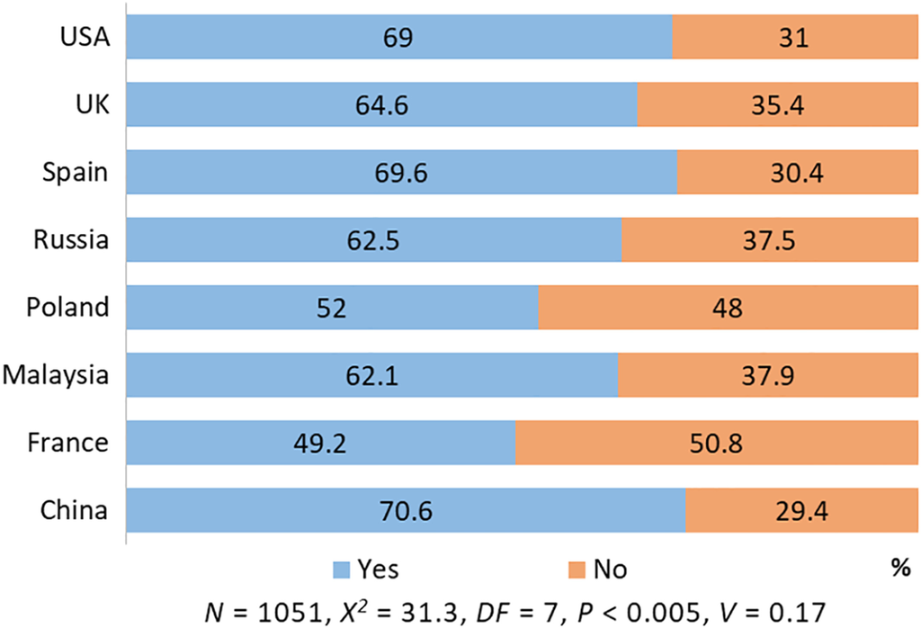

**Figure 4**

Open in figure viewer[PowerPoint](https://onlinelibrary.wiley.com/action/downloadFigures?id=leap1313-fig-0004&doi=10.1002%2Fleap.1313)

Do you use social media for any scholarly purpose?.

Table 8. To what extent do you use social media for each of the following purposes? (*M*, *SD*) (*N =* 638, *df* = 7, *p* < 0.05)

| Country case studies | China | France | Malaysia | Poland | Russia | Spain | UK | USA | Total | *F* | *η*<sup>2</sup> |
| --- | --- | --- | --- | --- | --- | --- | --- | --- | --- | --- | --- |
| Networking | 3.5, 1 | *3.8*, *1.2* | 4, 0.7 | 3.9, 1 | 4.1, 0.8 | 4.2, 0.9 | *4.3*, *0.7* | 4, 1 | 3.9, 1 | 7.9 | .08 |
| Current awareness | 4.1, 0.8 | 3.8, 1.3 | 4.1, 0.7 | 4.3, 0.7 | 3.6, 1 | 4.1, 0.9 | 4.2, 0.8 | 4.2, 0.8 | 4, 0.9 | 5.1 | .05 |
| Sharing research | 3.2, 1 | 3.9, 1.2 | 3.8, 1 | 3.9, 1 | 3.9, 0.9 | 4.1, 0.9 | 4, 1.2 | 3.8, 1.2 | 3.7, 1.1 | 7.2 | .07 |
| Research collaboration | *3.4*, *1* | *2.9*, *1.2* | 3.7, 1 | 3.4, 1 | *3.9*, *0.9* | 3.3, 1.1 | 3.3, 1.3 | *3.2*, *1.3* | 3.4, 1.1 | 5.5 | .06 |
| Building and showcasing your reputation | 3.2, 1 | 3.6, 1.2 | 3.7, 1.1 | 3.7, 1.1 | 3.6, 0.9 | 3.9, 1 | 3.8, 1.2 | 3.8, 1.2 | 3.6, 1.1 | 4.8 | .05 |
| Conducting original research | *3.2*, *1* | 2.3, 1.3 | *3*, *1.4* | *2.9*, *1.2* | *3.4*, *0.9* | 2.8, 1.2 | **2.2, 1.3** | *2.2*, *1.3* | 2.8, 1.3 | 12.7 | .13 |
| Testing research hypotheses | 3.1, 1.1 | 1.9, 1.2 | *2.5*, *1.4* | 2.4, 1.2 | **3.1, 0.8** | *2.8*, *1.3* | 1.8, 1.1 | 1.9, 1.2 | 2.5, 1.3 | 18.7 | .18 |
| Keeping up to date in your field | 3.7, 1 | 4.1, 1.2 | 3.9, 0.8 | 4.1, 0.8 | *3.8*, *0.8* | *4.3*, *0.8* | 4.1, 1 | 4.1, 1 | 4, 1 | 4 | .04 |

## CONCLUSIONS AND DISCUSSION

We have demonstrated a degree of diversity in terms of scholarly communication attitudes and practices of ECRs from the various countries represented in the study, which cannot be solely explained by the different make‐up of the samples. So, while globalization is conducive to commonality among researchers, especially as millennials who see themselves first and foremost as citizens of the world, local circumstances greatly influence scholarly attitudes and behaviour. These local circumstances can be that countries are at different stages in their scholarly development, government policies/interventions, and cultural differences.

Statistically speaking, China, Russia, France, and Malaysia are more likely to be different with respect to scholarly activity; however, most of the differences are moderate in terms of the effect size. The responses from the UK and USA stand out as being very similar, which is not surprising given their common roots. In terms of scholarly communications, the USA and UK are like ‘two peas in the same pod’. What renders them so similar, of course, is that they have much in common: (1) both countries are renowned because of the size and maturity of their research, and taken to represent the most advanced forefronts of science, they have largely been the holders of the monopoly over scientific credit (Stolte‐Heiskanen, 1987); (2) they are both English language countries whose language is the language of scholarly communication; and (3) key English‐language databases in the various disciplines are dominant.

Mainstream scientific countries, such as the USA and the UK, are less likely to rely on external factors such as number of downloads, authors' affiliation, recommendations, and journal rank for their decisions to read a paper compared to countries, such as China and Malaysia, something that previous studies have also found (Jamali *et al*., 2014). The UK, USA, and Spain were more positive towards open science and aspects of social media usage, such as using them to share links or promote research compared to China and Malaysia.

French ECRs certainly stand out, appearing not wanting to do, abide, or follow anything novel or innovative. This is because the French are frequently very critical of scholarly developments because they see them as introducing inequality and contributing towards the dismantlement of the existing scholarly system (Le Monde, 2019). Thus, many scholarly innovations and their corollary policies are critically labelled as “capitalism”, “neo‐liberalism”, and “commodification”. The atmosphere has changed, and this is related to the current political reforms. For instance, recent CNRS (French National Centre for Scientific Research) policy, instigated by President Macron, seeks to employ “Darwinian” principles to research funding (Mathews, 2020; Petit, 2019): those who are not productive might not be funded and be removed from the system and, hence, the strong dislike of metrics noted elsewhere (Nicholas *et al*., 2019). Besides, French policies on open science are very recent and still confusing, and they are not communicated well. Institutions, such as CNRS and INSERM (France's National Institute for Health and Medical Research), are developing their policies later than other countries, such as the UK, and struggling in applying them as researchers' behaviour remains resistant.

Another important point is that, in France, it is acceptable to talk about the individual uptake of scholarly innovations but not about the community uptake. Observed uptake is not the result of collective dynamics but of choices and *ad hoc* experiments, subject to the conditions of the context in which they are carried out (Boukacem‐Zeghmouri, Dillaerts, Lafouge, Bador, & Sauer‐Avargues, 2018). Those practicing OA are doing it by choice and opportunity, and not by compliance with the national policy.

Spanish ECRs are innovative in some respects and especially more positive about publishing OA because they can obtain citations sooner this way. The only limitation is the cost if they do not belong to well‐funded research units. They do use social media to promote their research and give access to their papers to a wider audience. They appreciate networking and collaboration in that they help them produce papers that can be published in the best outlets. It is in their focus to publish in high‐impact journals where they show themselves to be conservative. The strong competition for the few tenured positions available is the main reason for this.

Russian ECRs are open in that they like using Google for scholarly searching and are happy to find non‐peer reviewed materials as part of their search. Citation metrics, journal impact factor, and OA journals are also part of their professional lives. However, their publishing practices show contradictions in behaviour. Citation scores are put on a pedestal by the national excellence programme, and this encourages them to publish OA because they believe they can obtain more citations that way. Despite this, there are not many credible Russian OA journals to publish in. The situation is likely to change soon after the implementation of a new national excellence project “Science” (2018–2024, see https://futurerussia.gov.ru/nauka), which includes special support for ECRs.

Chinese ECRs are somewhat conservative in their publishing practices as they are less likely to publish in OA journals and prefer to not use social media to showcase their research, although they use it regularly to trace what others are doing and to test research hypotheses. Traditional journal‐based impact factors are still the most important metric, although they increasingly use altmetrics to find “must‐read” papers. The evaluation system and policies are the decisive factors, which influence Chinese ECRs' academic communication behaviour in every respect. ECRs do not have many choices themselves and are relatively passive compared to those in other countries ECRs.

Malaysian ECRs consistently have the highest mean value for searching, which in this study relates to using Google, GS, smartphone, and searching for non‐peer reviewed materials, which is perceived to be the modern way. We suspect this has something to do with the effect of uncertainty avoidance. Malaysia is a low uncertainty avoidance country; in other words, it is an uncertainty‐accepting society (Khosrowjerdi *et al*., 2019). People in such societies are more comfortable with ambiguity, more likely to take risks, and less dependent on structured rules – they do not feel obliged to follow a single route.

Polish ECRs are similar to other mainland European ECRs, especially French and Spanish ones. In 2019, reforms of science and higher education in Poland were initiated in order to ensure that Polish scientists keep pace with those from other countries and have suitable funding to accomplish this. Reforms mean that ECRs are increasingly focused on publishing in journals indexed in WoS and Scopus and to publish less and focus on quality. Polish researchers are positively inclined towards the idea of open science and OA. The Polish institutions financing grants (e.g. National Science Centre) are preparing to implement Plan S, so this might result in greater practice; however, high costs of OA may prove to be a big barrier for Polish researchers.

Finally, as to the future, the diversity in cultural and economic‐driven local circumstances is likely to remain with respect to scholarly communications. However, governmental and/or funder initiatives, which have already proven their ability to bring about changes, may help to level the field for researchers, especially as the new wave joining the scholarly workforce is ever more receptive to unifying notions, such as open science.

### Limitations

The study has limitations that should be taken into account when interpreting the results. Because the survey was online and was distributed using various means, it was not possible to calculate a response rate. Various subjects were not evenly represented in the data, and some of the questions (e.g. use of PubMed) were subject‐dependent. Due to ethical considerations, respondents were allowed to skip any questions and exit the survey at any point, and as a result, the number of respondents for different questions varies. The number of respondents from different countries was also uneven. The means used for the distribution of survey (publisher's list *etc*.) might have impacted the demographics of respondents.

## ACKNOWLEDGEMENTS

We acknowledge Dianyun Chen and Jiayun Wang of Wuhan University who helped with the Chinese coding; funding from the University of Malaya (Project No BKS079‐2017); Tomàs Baiget; and those organizations that helped distribute the questionnaire: Wiley, Emerald, Cambridge University Press, Public Library of Science, Eurodoc, Sense about Science, and UCL library.

## REFERENCES

[figure not shown]

## Citing Literature

[figure not shown]

[Volume33, Issue4](https://onlinelibrary.wiley.com/toc/17414857/2020/33/4)

October 2020

Pages 370-384

### Metrics

- Citations: 2

### Details

  © 2020 The Author(s). Learned Publishing © 2020 ALPSP.

### Research funding

  - Universiti Malaya. Grant Number: BKS079‐2017

### Keywords

  - [early career researchers](https://onlinelibrary.wiley.com/action/doSearch?field1=Keyword&text1=early%20career%20researchers)
  - [scholarly communications beliefs and practices](https://onlinelibrary.wiley.com/action/doSearch?field1=Keyword&text1=scholarly%20communications%20beliefs%20and%20practices)
  - [country comparisons](https://onlinelibrary.wiley.com/action/doSearch?field1=Keyword&text1=country%20comparisons)

### Publication History

  - Issue Online: 11 October 2020
  - Version of Record online: 04 June 2020
  - Manuscript accepted: 12 May 2020
  - Manuscript revised: 18 April 2020
  - Manuscript received: 16 February 2020

[Download PDF](https://onlinelibrary.wiley.com/doi/pdf/10.1002/leap.1313)

back